# BMA POCRM Simulation Study

Luka Kovacevic

20/08/2021

This simulation study aims to investigate the properties of four approaches to handling partial orderings in the continual reassessment method. These implementations are as follows

1. Partial Ordering Continual Reassessment Method proposed by Wages et al. (2011)
2. Point estimatation of the posterior mean of the working model
3. Mixture distribution of the probability of toxicity $\tau_i$ with allocation via the posterior density
4. Mixture distribution of the probability of toxicity $\tau_i$ with allocation via the expected value of $\tau_i$

These methods are outlined in detail in the associated implementation specification.

#### Scenarios

For this simulation study we consider a set of scenarios similar to those in the AGILE trial. We have three potential doses $d_1, d_2$ and $d_3$ for which we have the potential orderings
$$1: d_1 \rightarrow d_2 \rightarrow d_3,$$
$$2: d_1 \rightarrow d_3 \rightarrow d_2,$$
$$3: d_2 \rightarrow d_1 \rightarrow d_3.$$
Under scenarios 1, 2 and 3, respectively, we have the following true toxicity probabilities:

[output not shown]

A set of repeated simulations will be run to observe the general performance of the proposed methods under these scenarios followed by a set of single trial simulations to observe the behavior of each method and changes in the posterior model probabilities. The simulation parameters are specified as follows:

```r
ttl <- 0.4    # Target toxicity rate
cohortsize <- 1 # Cohort size for each inclusion
ncohort <- 20   # Number of cohorts
start_comb <- 2 # Starting combination
n_stop <- 100    # Number of patients needed on one combination to stop the trial
ntrial <- 1000   # Number of simulated trials

# obtains the mean changes in probability of toxicity and model probabilities
check_jumps <- function(hist, p.skel){
  diff <- matrix(0, nrow = dim(hist)[1] - 1, ncol = nrow(p.skel) + ncol(p.skel))
  for(i in 1:(dim(hist)[1] - 1)){
    diff[i,] <- abs(hist[i+1,3:(2+nrow(p.skel) + ncol(p.skel))] - hist[i,3:(2+nrow(p.skel) + ncol(p.skel))])
  }
  return(list(mean_prob = colMeans(diff[,1:nrow(p.skel)]),
              mean_tox = colMeans(diff[,(nrow(p.skel) + 1):(nrow(p.skel) + ncol(p.skel))])))
}
```

## Simulation Study

#### Repeated Trial Simulations

| Method | POCRM | BMA Point | BMA Mixture |
| --- | --- | --- | --- |
| Scenario 1 | (0.2798, 0.3380, 0.3822) | (0.3623, 0.3148, 0.3229) | (0.3342, 0.3490, 0.3168) |
| Scenario 2 | (0.3488, 0.1918, 0.4594) | (0.3973, 0.1893, 0.4134) | (0.4029, 0.2402, 0.3570) |
| Scenario 3 | (0.5126, 0.2533, 0.2341) | (0.4815, 0.2503, 0.2682) | (0.5120, 0.2416, 0.2463) |

#### Single Trial Simulations

In this section, we simulate each method under all three scenarios for only a single trial. Single trial simulations allow for changes in the posterior model probabilities to be observed and their behaviour for each different model can be investigated.

##### Scenario 1

```
## ################################
##
##  POCRM (Wages et al. (2011))
##
## ################################
##
## Seed: 514
##       n y     m1     m2     m3     d1     d2     d3 comb_select
##  [1,] 1 0 0.3340 0.2737 0.3923 0.2437 0.1117 0.4028           3
##  [2,] 1 0 0.3211 0.3211 0.3579 0.1128 0.0338 0.2452           3
##  [3,] 1 0 0.3110 0.3532 0.3357 0.0122 0.1609 0.0587           2
##  [4,] 1 0 0.3185 0.3185 0.3630 0.0453 0.0082 0.1362           3
##  [5,] 1 0 0.3123 0.3427 0.3450 0.0264 0.0035 0.0962           3
##  [6,] 1 0 0.3069 0.3613 0.3318 0.0021 0.0780 0.0191           2
##  [7,] 1 0 0.3137 0.3373 0.3490 0.0150 0.0015 0.0669           3
```

[output cut: 299 more lines]

##### Scenario 2

```
## ################################
##
##  POCRM (Wages et al. (2011))
##
## ################################
##
## Seed: 514
##       n y     m1     m2     m3     d1     d2     d3 comb_select
##  [1,] 1 0 0.3340 0.2737 0.3923 0.2437 0.1117 0.4028           3
##  [2,] 1 0 0.3211 0.3211 0.3579 0.1128 0.0338 0.2452           3
##  [3,] 1 1 0.3524 0.2208 0.4269 0.3320 0.1805 0.4915           1
##  [4,] 1 1 0.2619 0.2011 0.5370 0.4826 0.3227 0.6254           2
##  [5,] 1 0 0.2331 0.1245 0.6424 0.4176 0.2578 0.5698           1
##  [6,] 1 0 0.2624 0.1368 0.6008 0.3547 0.2001 0.5129           1
##  [7,] 1 0 0.2876 0.1468 0.5655 0.3062 0.1592 0.4665           3
```

[output cut: 299 more lines]

##### Scenario 3

```
## ################################
##
##  POCRM (Wages et al. (2011))
##
## ################################
##
## Seed: 514
##       n y     m1     m2     m3     d1     d2     d3 comb_select
##  [1,] 1 0 0.3340 0.2737 0.3923 0.2437 0.1117 0.4028           3
##  [2,] 1 0 0.3211 0.3211 0.3579 0.1128 0.0338 0.2452           3
##  [3,] 1 1 0.3524 0.2208 0.4269 0.3320 0.1805 0.4915           1
##  [4,] 1 1 0.2619 0.2011 0.5370 0.4826 0.3227 0.6254           2
##  [5,] 1 0 0.2331 0.1245 0.6424 0.4176 0.2578 0.5698           1
##  [6,] 1 0 0.2624 0.1368 0.6008 0.3547 0.2001 0.5129           1
##  [7,] 1 0 0.2876 0.1468 0.5655 0.3062 0.1592 0.4665           3
```

[output cut: 299 more lines]

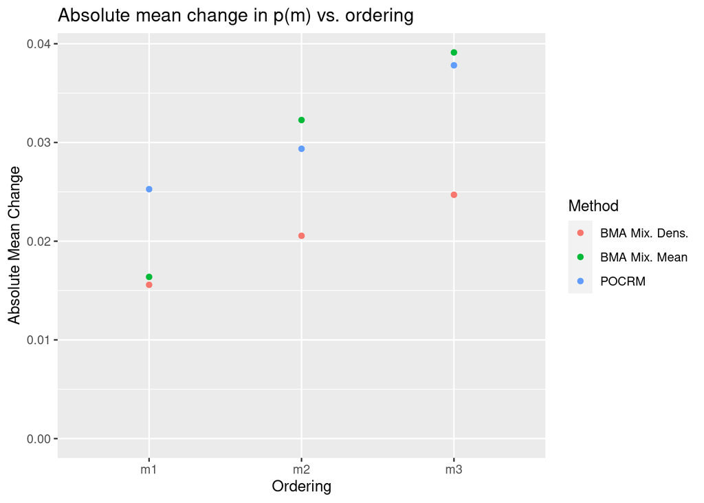

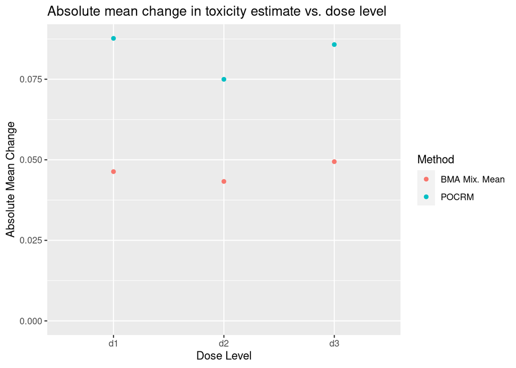